CS F364: Design and Analysis of Algorithms

# Probability Primer & Randomized Quicksort

Lecture 8 |2026-05-21

Tulasimohan Molli

BITS Pilani, Hyderabad Campus

# Probability Primer

- Probability Primer
- Randomized Quicksort Analysis

## Quick Quiz: Do you know these?

Before we dive in, let’s test your memory of these key terms:

- **Random Experiment**
- **Sample Space**
- **Outcome**
- **Event**
- **Random Variable**

*Let’s review their formal definitions.*

## Sample Space and Outcomes

- **Sample Space ($\Omega$):** The set of all possible *results* of a random experiment.
- Coin toss: $\Omega = \{H, T\}$
- Roll of a die: $\Omega = \{1, 2, 3, 4, 5, 6\}$
- **Outcome ($\omega$):** A single *result* of the experiment (an element of the sample space, $\omega \in \Omega$).
- **Event:** A subset of the sample space.
- Example: “Rolling an even number” $= \{2, 4, 6\}$

**Note on Randomness**

Randomness is a property of the **process** or **experiment**, and not of the **outcome** itself.

## Random Variables

- A **Random Variable (RV)** is a function $X: \Omega \to \mathbb{R}$ that assigns a real number to each outcome.
- **Examples:**
  - Number of heads in 3 coin tosses: $X \in \{0, 1, 2, 3\}$
  - Value shown on a die roll: $X \in \{1, 2, 3, 4, 5, 6\}$
  - In Quicksort: “number of comparisons between elements $i$ and $j$”
- Random variables can be **discrete** (countable values) or **continuous**.

## Expectation

The **expected value** (or mean) of a discrete random variable $X$ is:
$$E[X] = \sum_{x} x \cdot \Pr(X = x)$$

**Example:** Expected value of a fair die roll:
$$E[X] = 1 \cdot \frac{1}{6} + 2 \cdot \frac{1}{6} + 3 \cdot \frac{1}{6} + 4 \cdot \frac{1}{6} + 5 \cdot \frac{1}{6} + 6 \cdot \frac{1}{6} = 3.5$$

## Linearity of Expectation

For **any** random variables $X$ and $Y$:
$$E[X + Y] = E[X] + E[Y]$$

This holds **even if $X$ and $Y$ are dependent!**

**Example:** Expected sum of two dice rolls: - $E[X_1 + X_2] = E[X_1] + E[X_2] = 3.5 + 3.5 = 7$

This property is what makes analyzing randomized algorithms tractable.

## Indicator Random Variables

An **Indicator Random Variable** $I_A$ for an event $A$ is defined as:
$$I_A =
\begin{cases}
1 & \text{if event } A \text{ occurs} \\
0 & \text{otherwise}
\end{cases}$$

The expected value of an indicator variable is simply the probability of the event:
$$E[I_A] = 1 \cdot \Pr(A) + 0 \cdot \Pr(\text{not } A) = \Pr(A)$$

**Classic Example:** Expected number of heads in $n$ coin flips:

- Let $I_k$ be indicator that $k^{th}$ flip is heads.
- $E[I_k] = \Pr(\text{heads}) = 1/2$.
- $E[\text{total heads}] = E[\sum I_k] = \sum E[I_k] = n \cdot 1/2 = n/2$.

We’ll use this to count the expected number of comparisons in Quicksort!

# Randomized Quicksort Analysis

- Probability Primer
- Randomized Quicksort Analysis

## Randomized Quicksort

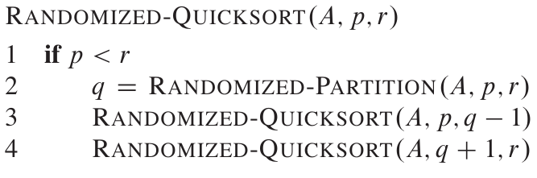

Randomized Quicksort

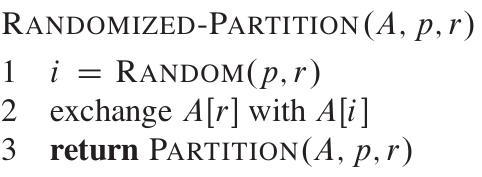

Randomized Partition

- The pivot is chosen **uniformly at random** from the array.
- This makes the algorithm’s performance independent of the input order.

## Key Idea of Analysis

- Focus on the **number of comparisons** made during partitioning.
- Each pair of elements is compared **at most once**.
- Let’s use **Indicator Random Variables**.

Let $X_{ij}$ be the random variable:
$$X_{ij} =
\begin{cases}
1, & \text{if elements } i \text{ and } j \text{ are compared} \\
0, & \text{otherwise}
\end{cases}$$

Total comparisons: $X = \sum_{i < j} X_{ij}$

## Probability of Comparison

Assume the elements are sorted: $z_1 < z_2 < \cdots < z_n$.

Elements $z_i$ and $z_j$ (where $i < j$) are compared **only if**:

- One of them is chosen as the pivot **first** among $\{z_i, z_{i+1}, \dots, z_j\}$.
- If any element between them is chosen first, they are never compared!

The number of elements in this set is $j - i + 1$. Since each is equally likely:
$$\Pr(X_{ij} = 1) = \frac{2}{j - i + 1}$$

## Expected Number of Comparisons

By **Linearity of Expectation**:
$$\mathbb{E}[X] = \sum_{i < j} \mathbb{E}[X_{ij}] = \sum_{i < j} \Pr(X_{ij} = 1)$$
$$\mathbb{E}[X] = \sum_{i=1}^{n-1} \sum_{j=i+1}^{n} \frac{2}{j - i + 1}$$

## Expected Number of Comparisons (Continued)

Let $k = j - i$:
$$\mathbb{E}[X] = \sum_{i=1}^{n-1} \sum_{k=1}^{n-i} \frac{2}{k + 1}$$

Now swap the order of summation:
$$\mathbb{E}[X] = \sum_{k=1}^{n-1} \sum_{i=1}^{n-k} \frac{2}{k + 1}$$

## Expected Number of Comparisons (Continued)

Simplifying:
$$\mathbb{E}[X] = \sum_{k=1}^{n-1} \frac{2(n-k)}{k + 1}$$

Bounding:
$$\mathbb{E}[X] \leq 2n \sum_{k=1}^{n-1} \frac{1}{k + 1}$$

## Final Bound

Using the bound for the Harmonic series $H_n = \sum_{k=1}^n \frac{1}{k} = O(\log n)$:
$$\mathbb{E}[X] = O(n \log n)$$

**Expected running time of Randomized Quicksort:**
$$\boxed{O(n \log n)}$$

**Exercise:** Show that $\mathbb{E}[X] = \Theta(n \log n)$.

## Conclusion

- Randomization eliminates bad input cases.
- Expected performance is $O(n \log n)$, which is asymptotically optimal for comparison-based sorting.
- The analysis uses **indicator random variables** and **linearity of expectation** — powerful tools for analyzing randomized algorithms.
- Randomized Quicksort is widely used in practice due to its simplicity, in-place nature, and excellent practical performance.